# Desafio Meantrix

Gustavo Konrad

1/23/2020

## Análise exploratória

Começamos carregando pacotes que iremos utilizar e importando os dados para análise.

```r
library(readr)
library(caret)
library(e1071)
library(ggplot2)
library(corrplot)
HR_Employee <- read_csv("../data/HR-Employee.csv")
summary(HR_Employee)
```

```
##       Age         Attrition         BusinessTravel       DailyRate
##  Min.   :18.00   Length:1470        Length:1470        Min.   : 102.0
##  1st Qu.:30.00   Class :character   Class :character   1st Qu.: 465.0
##  Median :36.00   Mode  :character   Mode  :character   Median : 802.0
##  Mean   :36.92                                         Mean   : 802.5
##  3rd Qu.:43.00                                         3rd Qu.:1157.0
##  Max.   :60.00                                         Max.   :1499.0
##   Department        DistanceFromHome   Education     EducationField
##  Length:1470        Min.   : 1.000   Min.   :1.000   Length:1470
##  Class :character   1st Qu.: 2.000   1st Qu.:2.000   Class :character
##  Mode  :character   Median : 7.000   Median :3.000   Mode  :character
##                     Mean   : 9.193   Mean   :2.913
##                     3rd Qu.:14.000   3rd Qu.:4.000
##                     Max.   :29.000   Max.   :5.000
##  EmployeeCount EmployeeNumber   EnvironmentSatisfaction    Gender
##  Min.   :1     Min.   :   1.0   Min.   :1.000           Length:1470
##  1st Qu.:1     1st Qu.: 491.2   1st Qu.:2.000           Class :character
##  Median :1     Median :1020.5   Median :3.000           Mode  :character
##  Mean   :1     Mean   :1024.9   Mean   :2.722
##  3rd Qu.:1     3rd Qu.:1555.8   3rd Qu.:4.000
##  Max.   :1     Max.   :2068.0   Max.   :4.000
##    HourlyRate     JobInvolvement    JobLevel       JobRole
##  Min.   : 30.00   Min.   :1.00   Min.   :1.000   Length:1470
##  1st Qu.: 48.00   1st Qu.:2.00   1st Qu.:1.000   Class :character
##  Median : 66.00   Median :3.00   Median :2.000   Mode  :character
##  Mean   : 65.89   Mean   :2.73   Mean   :2.064
##  3rd Qu.: 83.75   3rd Qu.:3.00   3rd Qu.:3.000
##  Max.   :100.00   Max.   :4.00   Max.   :5.000
##  JobSatisfaction MaritalStatus      MonthlyIncome    MonthlyRate
##  Min.   :1.000   Length:1470        Min.   : 1009   Min.   : 2094
##  1st Qu.:2.000   Class :character   1st Qu.: 2911   1st Qu.: 8047
##  Median :3.000   Mode  :character   Median : 4919   Median :14236
##  Mean   :2.729                      Mean   : 6503   Mean   :14313
##  3rd Qu.:4.000                      3rd Qu.: 8379   3rd Qu.:20462
##  Max.   :4.000                      Max.   :19999   Max.   :26999
##  NumCompaniesWorked    Over18            OverTime         PercentSalaryHike
##  Min.   :0.000      Length:1470        Length:1470        Min.   :11.00
##  1st Qu.:1.000      Class :character   Class :character   1st Qu.:12.00
##  Median :2.000      Mode  :character   Mode  :character   Median :14.00
##  Mean   :2.693                                            Mean   :15.21
```

[output cut: 8 more lines]

```
##  Max.   :4.000     Max.   :4.000            Max.   :80    Max.   :3.0000
##  TotalWorkingYears TrainingTimesLastYear WorkLifeBalance YearsAtCompany
##  Min.   : 0.00     Min.   :0.000         Min.   :1.000   Min.   : 0.000
##  1st Qu.: 6.00     1st Qu.:2.000         1st Qu.:2.000   1st Qu.: 3.000
##  Median :10.00     Median :3.000         Median :3.000   Median : 5.000
##  Mean   :11.28     Mean   :2.799         Mean   :2.761   Mean   : 7.008
##  3rd Qu.:15.00     3rd Qu.:3.000         3rd Qu.:3.000   3rd Qu.: 9.000
##  Max.   :40.00     Max.   :6.000         Max.   :4.000   Max.   :40.000
##  YearsInCurrentRole YearsSinceLastPromotion YearsWithCurrManager
##  Min.   : 0.000     Min.   : 0.000          Min.   : 0.000
##  1st Qu.: 2.000     1st Qu.: 0.000          1st Qu.: 2.000
##  Median : 3.000     Median : 1.000          Median : 3.000
##  Mean   : 4.229     Mean   : 2.188          Mean   : 4.123
##  3rd Qu.: 7.000     3rd Qu.: 3.000          3rd Qu.: 7.000
##  Max.   :18.000     Max.   :15.000          Max.   :17.000
```

### Variâncias próximas de zero

```r
zeroVars <- nearZeroVar(HR_Employee)
summary(HR_Employee[zeroVars])
```

```
##  EmployeeCount    Over18          StandardHours
##  Min.   :1     Length:1470        Min.   :80
##  1st Qu.:1     Class :character   1st Qu.:80
##  Median :1     Mode  :character   Median :80
##  Mean   :1                        Mean   :80
##  3rd Qu.:1                        3rd Qu.:80
##  Max.   :1                        Max.   :80
```

```r
HR_Employee <- HR_Employee[-zeroVars]
```

A função nearZeroVar identifica, de maneira geral, variáveis com variância próxima de zero. Tais variáveis, que adicionam pouca ou nenhuma informação ao modelo, podem ser descartadas para melhorar a performance no treinamento. Podemos ver acima que as variáveis identificadas possuem variância nula, e portanto poderiam proveitosamente ser descartadas. Caso houvessem variáveis com variância baixa, mas não nula, seu descarte deve ser considerado com cuidado.

### Correlações

Podemos analisar correlações entre variáveis independentes e a variável dependente Attrition, mas antes precisamos gerar dummy variables.

```r
dmy <- dummyVars("~ .", HR_Employee, fullRank=T)
enc_HR <- data.frame(predict(dmy, HR_Employee))
correlations <- cor(enc_HR)
attrition_corrs <- correlations["AttritionYes",][-2] # removendo autocorrelação
attrition_corrs
```

```
##                              Age  BusinessTravelTravel_Frequently
##                    -0.1592050069                     0.1151427655
##      BusinessTravelTravel_Rarely                        DailyRate
##                    -0.0495378384                    -0.0566519919
## DepartmentResearch...Development                  DepartmentSales
##                    -0.0852929276                     0.0808552021
##                 DistanceFromHome                        Education
##                     0.0779235830                    -0.0313728196
##      EducationFieldLife.Sciences          EducationFieldMarketing
##                    -0.0327031477                     0.0557806657
##            EducationFieldMedical              EducationFieldOther
##                    -0.0469987159                    -0.0178975168
##   EducationFieldTechnical.Degree                   EmployeeNumber
##                     0.0693545948                    -0.0105772428
##          EnvironmentSatisfaction                       GenderMale
##                    -0.1033689783                     0.0294532532
##                       HourlyRate                   JobInvolvement
##                    -0.0068455496                    -0.1300159568
##                         JobLevel           JobRoleHuman.Resources
##                    -0.1691047509                     0.0362150821
##     JobRoleLaboratory.Technician                   JobRoleManager
##                     0.0982904855                    -0.0833163842
##    JobRoleManufacturing.Director         JobRoleResearch.Director
##                    -0.0829939241                    -0.0888698417
##        JobRoleResearch.Scientist           JobRoleSales.Executive
##                    -0.0003595713                     0.0197743685
##      JobRoleSales.Representative                  JobSatisfaction
##                     0.1572342701                    -0.1034811261
##             MaritalStatusMarried              MaritalStatusSingle
##                    -0.0909836512                     0.1754185536
##                    MonthlyIncome                      MonthlyRate
##                    -0.1598395824                     0.0151702125
##               NumCompaniesWorked                      OverTimeYes
##                     0.0434937391                     0.2461179942
##                PercentSalaryHike                PerformanceRating
##                    -0.0134782021                     0.0028887517
##         RelationshipSatisfaction                 StockOptionLevel
##                    -0.0458722789                    -0.1371449189
##                TotalWorkingYears            TrainingTimesLastYear
##                    -0.1710632461                    -0.0594777986
##                  WorkLifeBalance                   YearsAtCompany
##                    -0.0639390472                    -0.1343922140
##               YearsInCurrentRole          YearsSinceLastPromotion
##                    -0.1605450043                    -0.0330187751
##             YearsWithCurrManager
##                    -0.1561993159
```

```r
max(attrition_corrs)
```

```
## [1] 0.246118
```

```r
min(attrition_corrs)
```

```
## [1] -0.1710632
```

Muitas variáveis parecem contribuir em alguma medida para a variação em AttritionYes, com a variável OverTimeYes tendo a maior correlação positiva - indicando que sobrecarregamento do funcionário pode ser um dos principais fatores para a saída do mesmo - e a variável TotalWorkingYears tendo a maior correlação negativa - indicando que funcionários que estão à mais tempo no mercado de trabalho podem ter menor disposição à sair do seu emprego atual.

Podemos também plotar clusters de variáveis correlacionadas utilizando o pacote corrplot. Exportamos a imagem para um arquivo png para melhor visualização.

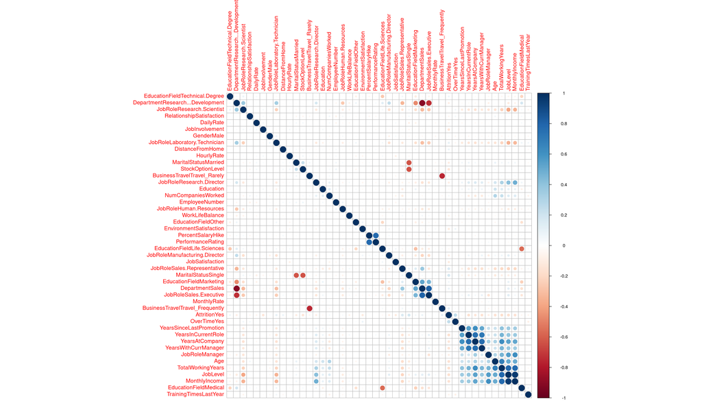

```r
corrMatrix <- corrplot(correlations, order="hclust", tl.cex=1)
```

```r
dev.print(file="corrplot.png", device=png, width=1920, height=1080)
```

Identificamos correlações esperadas entre variáveis que indicam o tempo corrido desde algum evento (anos desde que entrou na companhia, anos desde a última promoção, etc). Correlações entre idade, tempo no mercado de trabalho e salário mensal também não são inesperadas. Caso tais correlações venham a ser problemáticas (como podem ser no caso de modelos lineares), ou caso queiramos otimizar o modelo, podemos aplicar Principal Component Analysis para gerar features independentes entre si.

### Assimetria

Para verificar se temos features com distribuições assimétricas, utilizamos a função skewness do pacote e1071.

```r
skewValues <- apply(enc_HR, 2, skewness)
skewValues
```

```
##                              Age                     AttritionYes
##                      0.412443243                      1.840603819
##  BusinessTravelTravel_Frequently      BusinessTravelTravel_Rarely
##                      1.591813043                     -0.922106985
##                        DailyRate DepartmentResearch...Development
##                     -0.003511391                     -0.645616381
##                  DepartmentSales                 DistanceFromHome
##                      0.854411573                      0.956163540
##                        Education      EducationFieldLife.Sciences
##                     -0.289090164                      0.356191223
##          EducationFieldMarketing            EducationFieldMedical
##                      2.520630939                      0.792497676
##              EducationFieldOther   EducationFieldTechnical.Degree
##                      3.867214035                      2.866744428
##                   EmployeeNumber          EnvironmentSatisfaction
##                      0.016540210                     -0.320998308
##                       GenderMale                       HourlyRate
##                     -0.407831781                     -0.032245042
##                   JobInvolvement                         JobLevel
##                     -0.497402643                      1.023309576
##           JobRoleHuman.Resources     JobRoleLaboratory.Technician
##                      5.025364918                      1.698132940
##                   JobRoleManager    JobRoleManufacturing.Director
##                      3.385690560                      2.689346485
##         JobRoleResearch.Director        JobRoleResearch.Scientist
##                      3.924421023                      1.509128923
##           JobRoleSales.Executive      JobRoleSales.Representative
##                      1.338098805                      3.839343825
##                  JobSatisfaction             MaritalStatusMarried
##                     -0.328999464                      0.169138192
##              MaritalStatusSingle                    MonthlyIncome
##                      0.772295727                      1.367022404
##                      MonthlyRate               NumCompaniesWorked
##                      0.018539911                      1.024377223
##                      OverTimeYes                PercentSalaryHike
##                      0.962521412                      0.819452964
##                PerformanceRating         RelationshipSatisfaction
##                      1.917962271                     -0.302209830
##                 StockOptionLevel                TotalWorkingYears
##                      0.967003703                      1.114892944
##            TrainingTimesLastYear                  WorkLifeBalance
##                      0.551995858                     -0.551353300
##                   YearsAtCompany               YearsInCurrentRole
##                      1.760930007                      0.915491836
##          YearsSinceLastPromotion             YearsWithCurrManager
##                      1.980242248                      0.831750843
```

AttritionYes, que codifica Attrition, nossa variável target, é uma das variáveis que apresenta assimetria. Plotamos sua frequência relativa para inspeção visual.

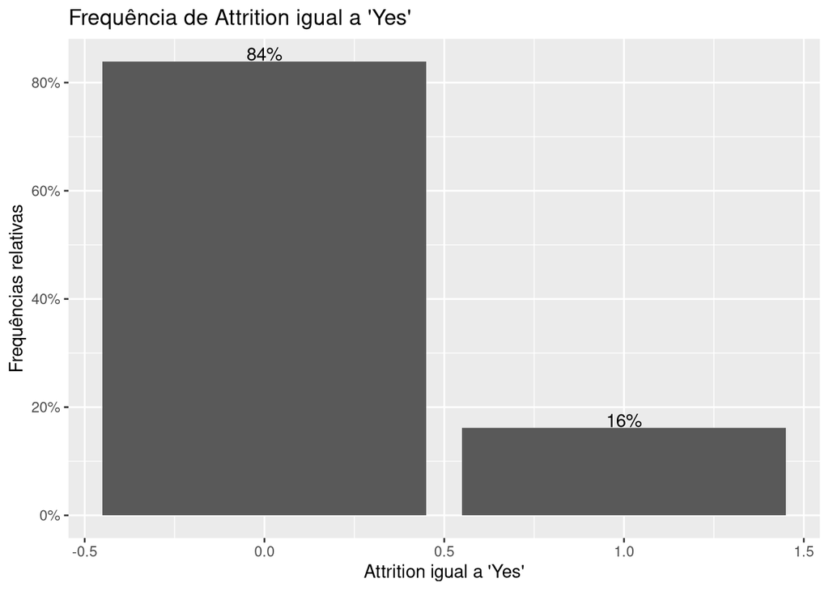

```r
ggplot(enc_HR, aes(x = AttritionYes)) +
  geom_bar(aes(y = (..count..)/sum(..count..))) +
  scale_y_continuous(labels = scales::percent) +
  geom_text(aes(label= scales::percent(..prop..), y=..prop..), stat="count", vjust = -.075) +
  xlab("Attrition igual a 'Yes'") +
  ylab("Frequências relativas") +
  ggtitle("Frequência de Attrition igual a 'Yes'")
```

```r
dev.print(file="attrition.png", device=png, width=800)
```

Fica evidente que Attrition é igual a “Yes” (ou AttritionYes == 1) em apenas 16% da população. Um algoritmo que estimasse Attrition = “No” para todo e qualquer caso teria, portanto, uma exatidão próxima de 84% neste dataset. Dada tal assimetria, podemos inferir que uma medida de performance baseada não na exatidão, mas na precisão e recall (identificação correta de negativos e positivos vs. falsos negativos e falsos positivos), como a estatística F1 (média harmônica entre precisão e recall), pode representar melhor a qualidade do modelo.

Além disso, na presença de variáveis com distribuições altamente assimétricas, poderíamos, caso fosse conveniente, aplicar a transformação Box-Cox no pré-processamento dos dados para corrigir tal assimetria.